# Wheat

Keenan Lee

27 August 2018

```r
my_data2017 <- read_excel("caigeyieldtrials2017_breadwheat_alldata.xlsx")

seeds = my_data2017$SOURCE
yield = my_data2017$GrainYieldtha
yield = as.numeric(yield)
genotype = as.factor(my_data2017$GID)
my_data2017 = my_data2017[!is.na(my_data2017$GrainYieldtha), ] #for removing na values.
```

# 2017

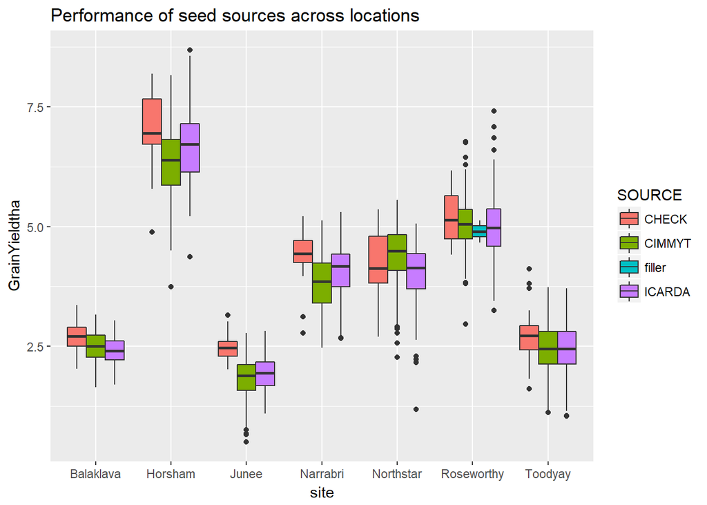

```r
ggplot() +
  geom_boxplot(data = my_data2017, mapping = aes(site, GrainYieldtha, fill=SOURCE)) + ggtitle("Performance of seed sources across locations")
```

### Obeservations

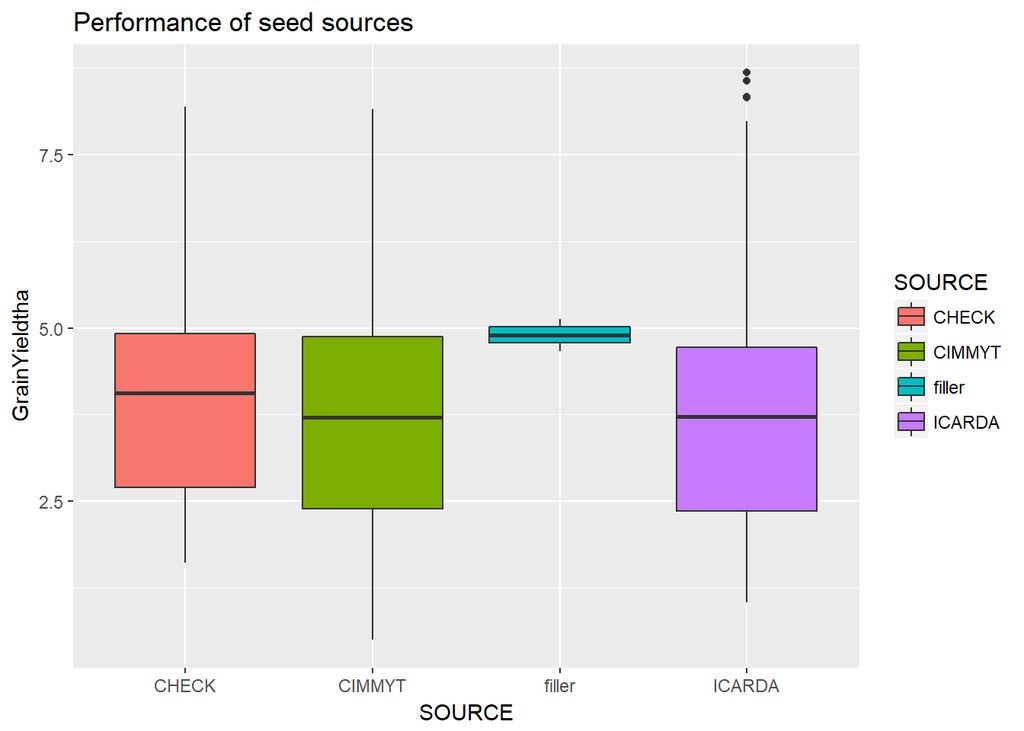

### Observations

Filler has a far lower spread compared to the other sources. We could investigate this as this consistency may be due to a specific gene. However this may be due to low sample size. Filler only had two entries so it is not useful for analysis due to this low sample size.

ICARDA has many outliers compared to the other sources. We could investiage this to determine if it is a certain gene thread which is causing these outliers.

I tried graphing genotypes vs yield and while it worked, I do not think it will be useful as there are many genotypes. I am not sure what to do with this.

I manually deleted rows with NA values in the dataset as I am unsure how to deal with them. I will ask my mentors how to deal with this problem.

```r
icarda_sub <- my_data2017 %>%
filter(SOURCE  == "ICARDA")
```

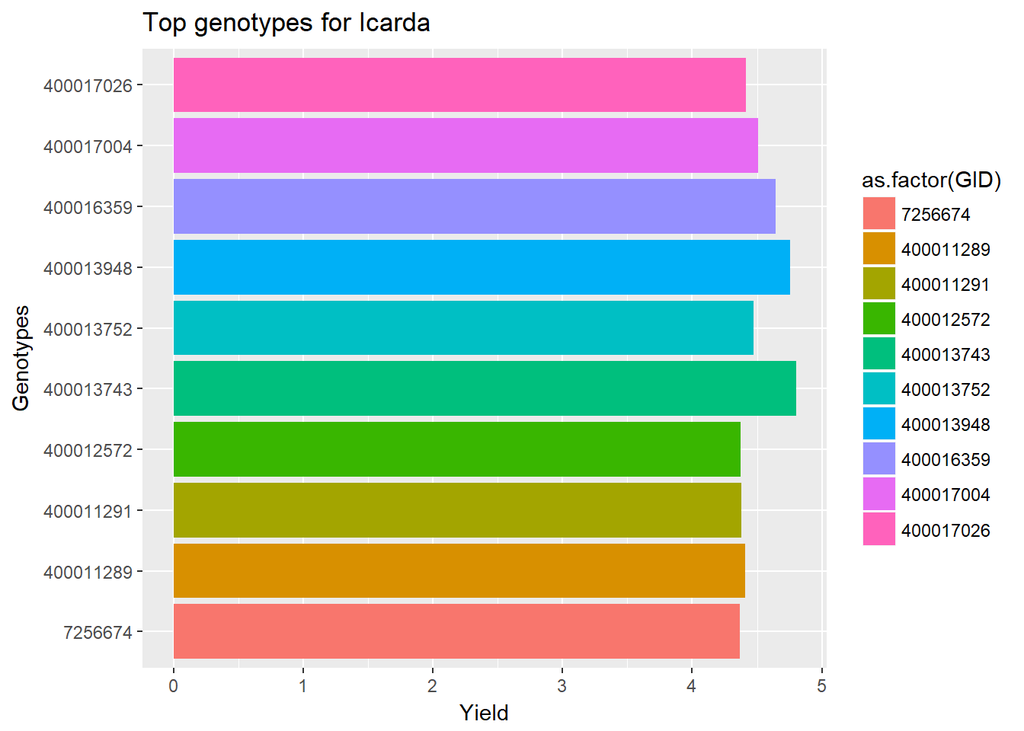

```r
#This creates the icarda_geno.
icarda_geno = icarda_sub %>%

      group_by(GID) %>%
      summarize(
      # averages
      mediangeno = median(as.numeric(GrainYieldtha))) %>%
        arrange(desc(mediangeno)) %>%
        slice(1:10)

p <- ggplot(icarda_geno, aes(x = as.factor(GID), y=mediangeno, fill = as.factor(GID))) +
    geom_bar(stat='identity') +

    labs(x = "Genotypes", y = "Yield") + ggtitle("Top genotypes for Icarda") + coord_flip()
print(p)
```

### Observations

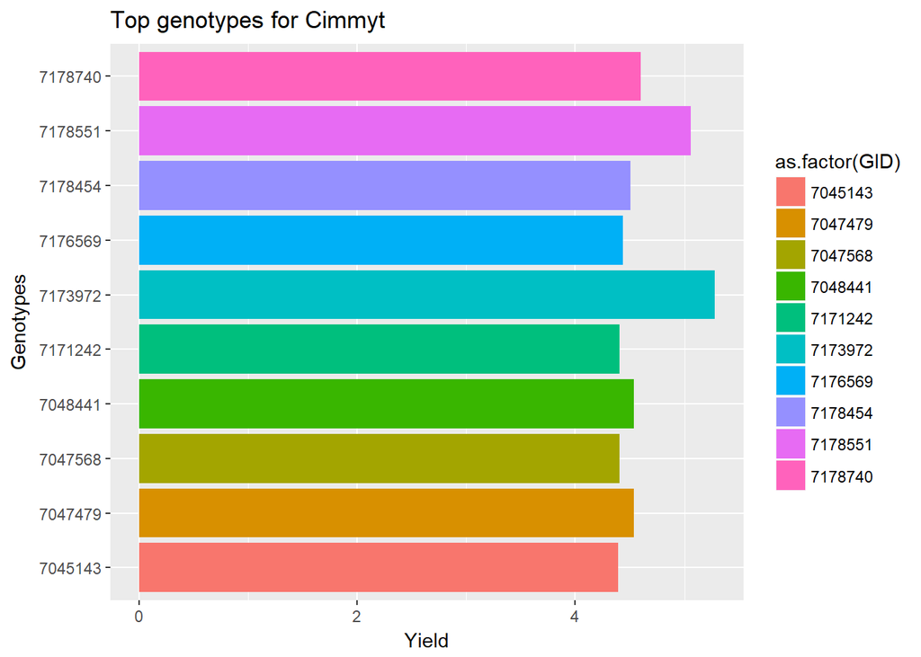

```r
cimmyt_sub = my_data2017 %>%
  filter(SOURCE == "CIMMYT")

cimmyt_geno = cimmyt_sub %>%

      group_by(GID) %>%
      summarize(
      # averages
      mediangeno = median(as.numeric(GrainYieldtha))) %>%
        arrange(desc(mediangeno)) %>%
        slice(1:10)
q <- ggplot(data = cimmyt_geno, aes(x = as.factor(GID) , y=mediangeno, fill = as.factor(GID))) +
    geom_bar(stat='identity') + ggtitle("Top genotypes for Cimmyt") +

    labs(x = "Genotypes", y = "Yield") + coord_flip()
print(q)
```

### Observations

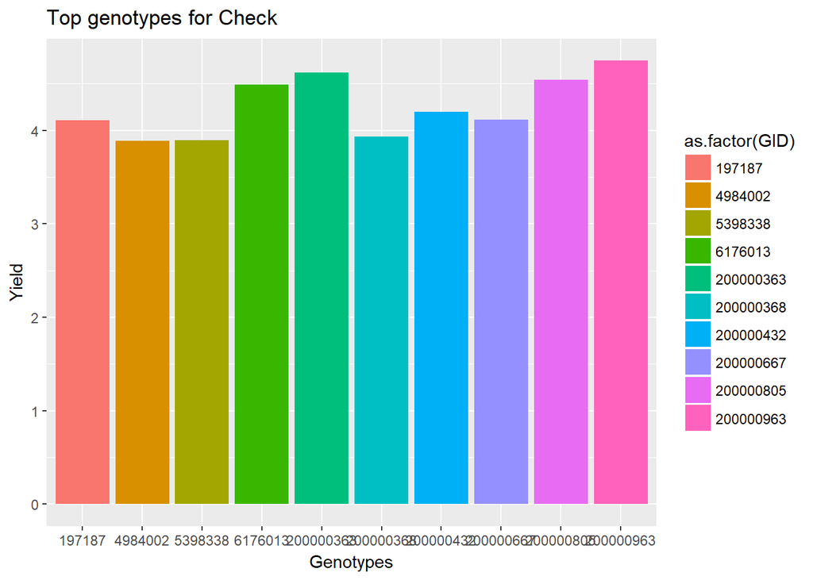

```r
check_sub = my_data2017 %>%
  filter(SOURCE == "CHECK")

check_geno = check_sub %>%

      group_by(GID) %>%
      summarize(
      # averages
      mediangeno = median(as.numeric(GrainYieldtha))) %>%
        arrange(desc(mediangeno)) %>%
        slice(1:10)

r <- ggplot(check_geno, aes(x = as.factor(GID), y=mediangeno, fill = as.factor(GID))) +
    geom_bar(stat='identity',labels = check_geno$GID) +

    labs(x = "Genotypes", y = "Yield") + ggtitle("Top genotypes for Check")
print(r)
```

### Observations

For check, the top performing genotypes all seem to start with 2000… for the most part.

## Top ten genotypes overall and how they perform across the different sources (not completed).

```r
topgeno = my_data2017 %>%

      group_by(GID) %>%
      summarize(
      # averages
      mediangeno = median(as.numeric(GrainYieldtha))) %>%
        arrange(desc(mediangeno)) %>%
        slice(1:10)
topgeno
```

```
## # A tibble: 10 x 2
##           GID mediangeno
##         <dbl>      <dbl>
##  1   7173972.       5.28
##  2   7178551.       5.06
##  3     30567.       4.90
##  4 400013743.       4.80
##  5 400013948.       4.75
##  6 200000963.       4.75
##  7 400016359.       4.64
##  8 200000363.       4.62
##  9   7178740.       4.60
## 10   7047479.       4.54
```

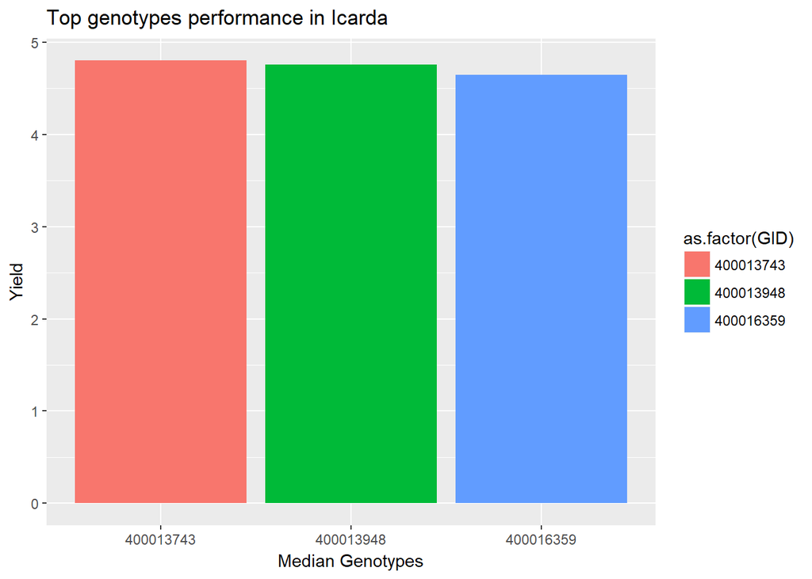

```r
genoicarda = subset(icarda_sub, GID %in% topgeno$GID)


icardamedian <- genoicarda %>%
  group_by(GID) %>%
  summarize(
    mediangeno = median(as.numeric(GrainYieldtha))
  )

ggplot(icardamedian, aes(x = as.factor(GID), y=mediangeno, fill = as.factor(GID))) +
    geom_bar(stat='identity') +

    labs(x = "Median Genotypes", y = "Yield") + ggtitle("Top genotypes performance in Icarda")
```

# 2016

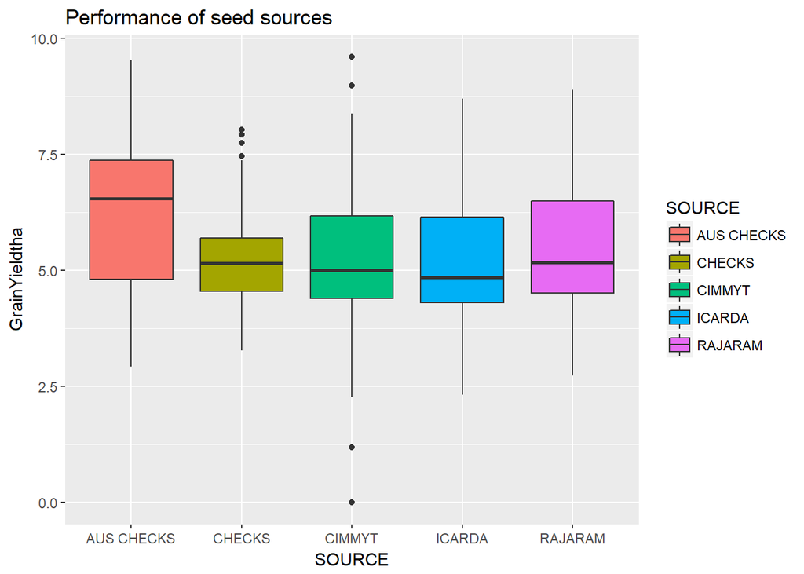

```r
my_databalaklava <- read_excel("2016\\caigeyieldtrials2016_breadwheat_balaklava.xlsx")

my_datahorsham <- read_excel("2016\\caigeyieldtrials2016_breadwheat_horsham.xlsx")



my_datajunee <- read_excel("2016\\caigeyieldtrials2016_breadwheat_junee.xlsx")


my_datanorthstar <- read_excel("2016\\caigeyieldtrials2016_breadwheat_northstar.xlsx")

my_datatoodyay <- read_excel("2016\\caigeyieldtrials2016_breadwheat_toodyay.xlsx")



my_data2016 <- read_excel("2016.xlsx")
my_data2016$GrainYieldtha <- as.numeric(my_data2016$GrainYieldtha)

my_data2016 = my_data2016[!is.na(my_data2016$GrainYieldtha), ] #for removing na values.


ggplot() +
  geom_boxplot(data = my_data2016, mapping = aes(SOURCE, GrainYieldtha, fill = SOURCE)) + ggtitle("Performance of seed sources")
```

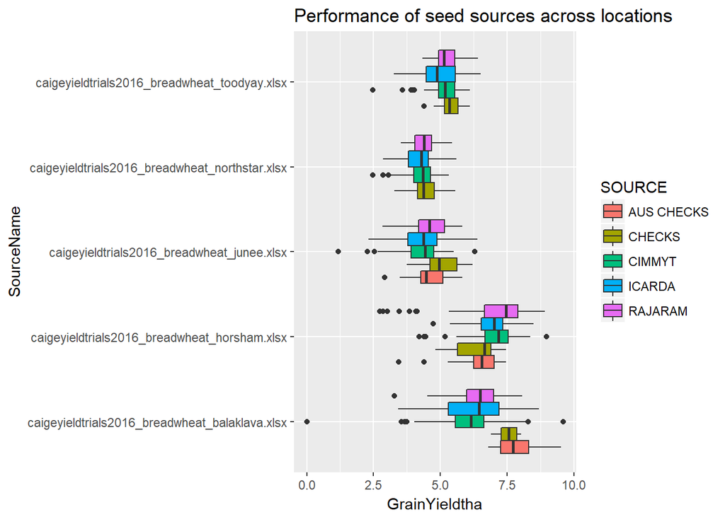

```r
ggplot() +
  geom_boxplot(data = my_data2016, mapping = aes(SourceName, GrainYieldtha, fill=SOURCE)) + coord_flip() + ggtitle("Performance of seed sources across locations")
```

## Performance of the top genotypes across different locations

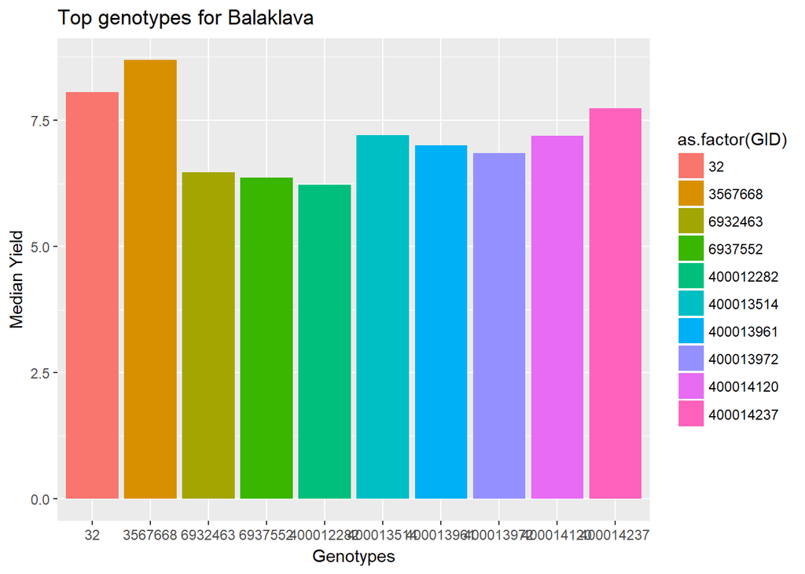

```r
#This the subset of the top 10 overall genotypes.
my_datatop <- my_data2016 %>%
  group_by(GID) %>%
      summarize(
      # averages
      mediangeno = median(as.numeric(GrainYieldtha))) %>%
        arrange(desc(mediangeno)) %>%
        slice(1:10)




genobalaklava = subset(my_databalaklava, GID %in% my_datatop$GID)

genobalaklava <- genobalaklava%>%
  group_by(GID) %>%
  summarize(
    mediangeno = median(as.numeric(GrainYieldtha))
  )


genohorsham = subset(my_datahorsham, GID %in% my_datatop$GID)

genohorsham <- genohorsham %>%
  group_by(GID) %>%
  summarize(
    mediangeno = median(as.numeric(GrainYieldtha))
  )


genojunee = subset(my_datajunee, GID %in% my_datatop$GID)

genojunee <- genojunee %>%
  group_by(GID) %>%
  summarize(
    mediangeno = median(as.numeric(GrainYieldtha))
  )


genonorthstar = subset(my_datanorthstar, GID %in% my_datatop$GID)

genonorthstar <- genonorthstar %>%
  group_by(GID) %>%
  summarize(
    mediangeno = median(as.numeric(GrainYieldtha))
  )


ggplot(genobalaklava, aes(x = as.factor(GID), y=mediangeno, fill = as.factor(GID))) +
    geom_bar(stat='identity') +

    labs(x = "Genotypes", y = "Median Yield") + ggtitle("Top genotypes for Balaklava")
```

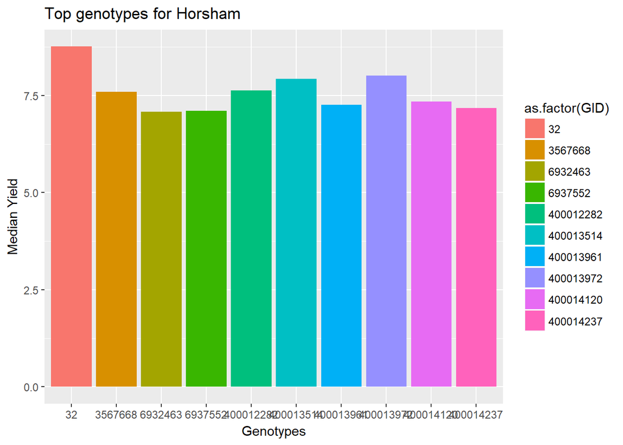

```r
ggplot(genohorsham, aes(x =as.factor(GID), y= mediangeno, fill = as.factor(GID))) +
    geom_bar(stat='identity') +
    labs(x = "Genotypes", y = "Median Yield") + ggtitle("Top genotypes for Horsham")
```

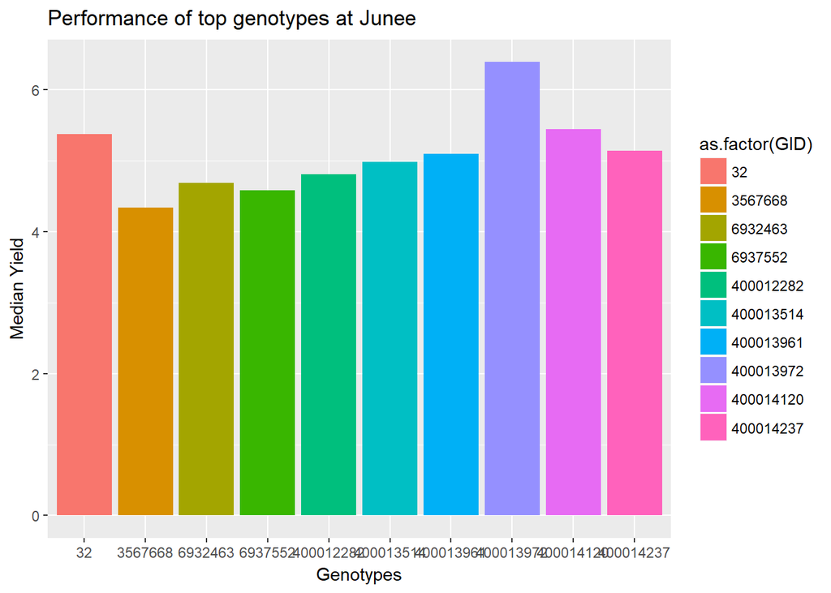

```r
ggplot(genojunee, aes(x =as.factor(GID), y= mediangeno, fill = as.factor(GID))) +
    geom_bar(stat='identity') +
    labs(x = "Genotypes", y = "Median Yield") + ggtitle("Performance of top genotypes at Junee")
```

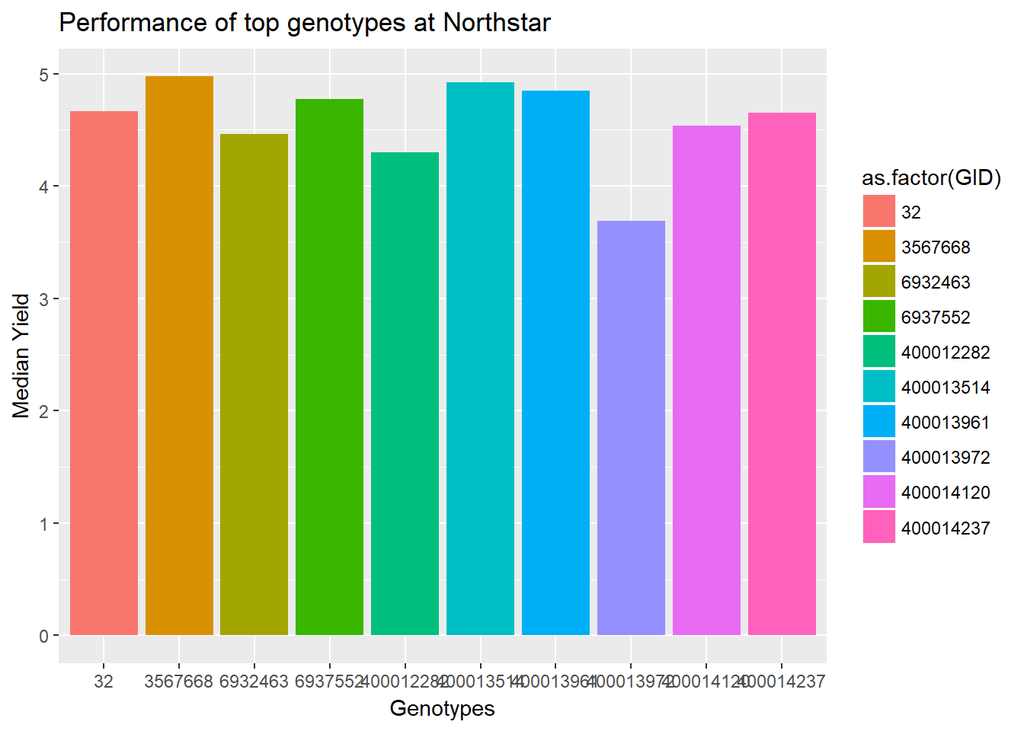

```r
ggplot(genonorthstar, aes(x =as.factor(GID), y= mediangeno, fill = as.factor(GID))) +
    geom_bar(stat='identity') +
    labs(x = "Genotypes", y = "Median Yield") + ggtitle("Performance of top genotypes at Northstar")
```

# 2014

```r
my_data2014 <- read_excel("2014.xlsx")

seeds = my_data2014$SOURCE
yield = my_data2014$Grainyieldtha
yield = as.numeric(yield)
genotype = as.factor(my_data2014$GID)

my_data2014 = my_data2014[!is.na(my_data2014$Grainyieldtha), ] #for removing na values.

my_data2014$Grainyieldtha <- as.numeric(my_data2014$Grainyieldtha)
```

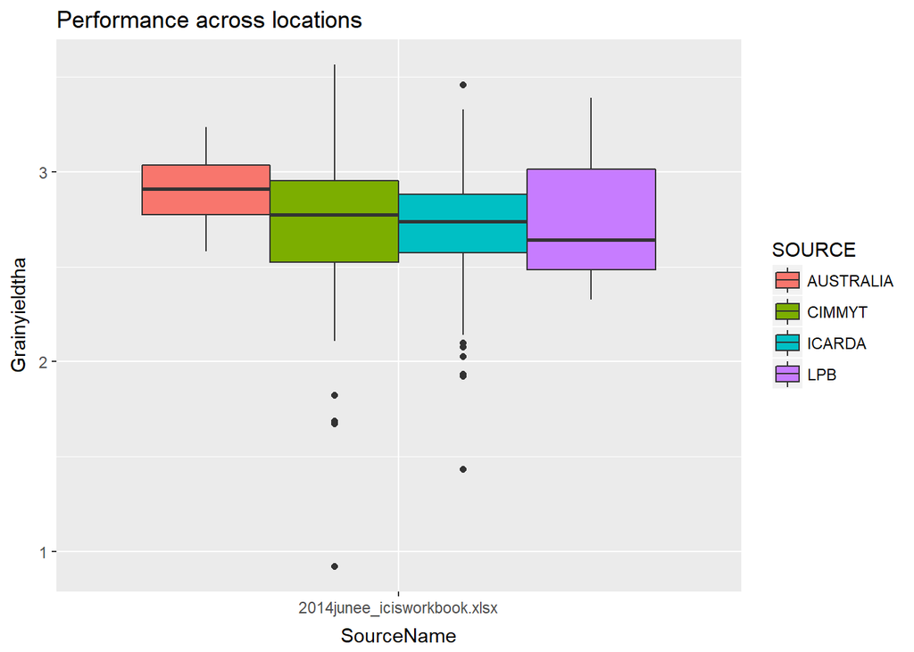

```r
ggplot() +
  geom_boxplot(data = my_data2014, mapping = aes(SourceName, Grainyieldtha, fill=SOURCE)) + ggtitle("Performance across locations")
```

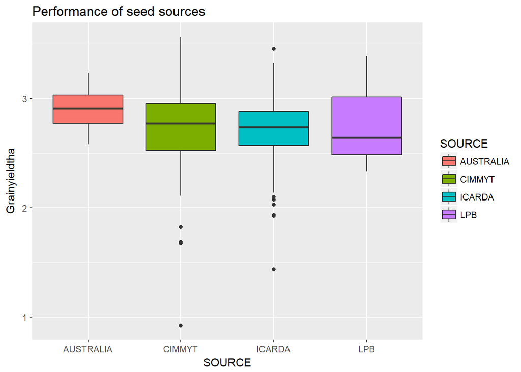

```r
ggplot() +
  geom_boxplot(data = my_data2014, mapping = aes(SOURCE, Grainyieldtha, fill = SOURCE)) + ggtitle("Performance of seed sources")
```

## Performance of the top genotypes across different locations

```r
my_datajunee <- read_excel("2014\\2014junee_icisworkbook.xlsx")

my_datakalkee <- read_excel("2014\\2014kalkee_icisworkbook.xlsx")

my_datamukinbudin <- read_excel("2014\\2014mukinbudin_icisworkbook.xlsx")

my_dataroseworthy <- read_excel("2014\\2014roseworthy_icisworkbook.xlsx")

my_datatoodyay <- read_excel("2014\\2014toodyay_icisworkbook.xlsx")

my_datatop <- my_data2014 %>%
  group_by(GID) %>%
      summarize(
      # averages
      mediangeno = median(as.numeric(Grainyieldtha))) %>%
        arrange(desc(mediangeno)) %>%
        slice(1:10)
genojunee = subset(my_datajunee, GID %in% my_datatop$GID)

genojunee <- genojunee %>%
  group_by(GID) %>%
  summarize(
    mediangeno = median(as.numeric(Grainyieldtha))
  )
genokalkee = subset(my_datakalkee, GID %in% my_datatop$GID)

genokalkee <- genokalkee %>%
  group_by(GID) %>%
  summarize(
    mediangeno = median(as.numeric(GrainYieldtha))
  )
genomukinbudin = subset(my_datamukinbudin, GID %in% my_datatop$GID)

genomukinbudin <- genomukinbudin %>%
  group_by(GID) %>%
  summarize(
    mediangeno = median(as.numeric(GrainYieldtha))
  )
genoroseworthy = subset(my_dataroseworthy, GID %in% my_datatop$GID)

genoroseworthy <- genoroseworthy %>%
  group_by(GID) %>%
  summarize(
    mediangeno = median(as.numeric(Grainyieldtha))
  )
```

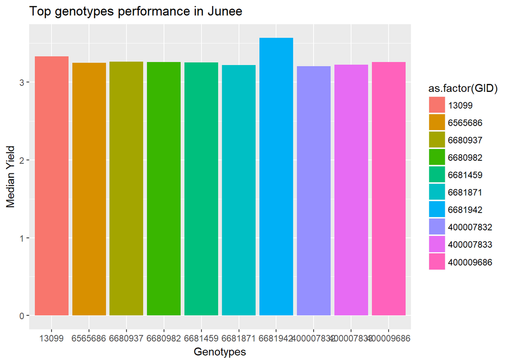

```r
ggplot(genojunee, aes(x = as.factor(GID), y=mediangeno, fill = as.factor(GID))) +
    geom_bar(stat='identity') +

    labs(x = "Genotypes", y = "Median Yield") + ggtitle("Top genotypes performance in Junee")
```

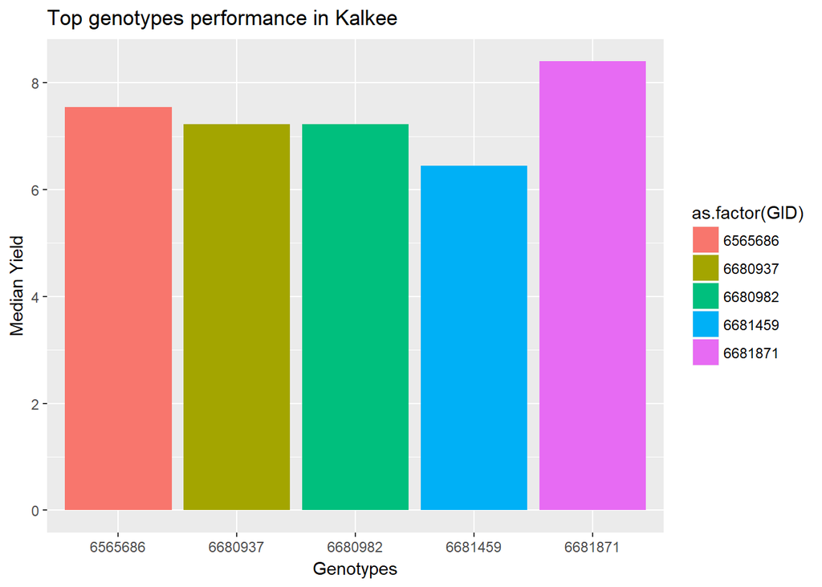

```r
ggplot(genokalkee, aes(x = as.factor(GID), y=mediangeno, fill = as.factor(GID))) +
    geom_bar(stat='identity') +

    labs(x = "Genotypes", y = "Median Yield") + ggtitle("Top genotypes performance in Kalkee")
```

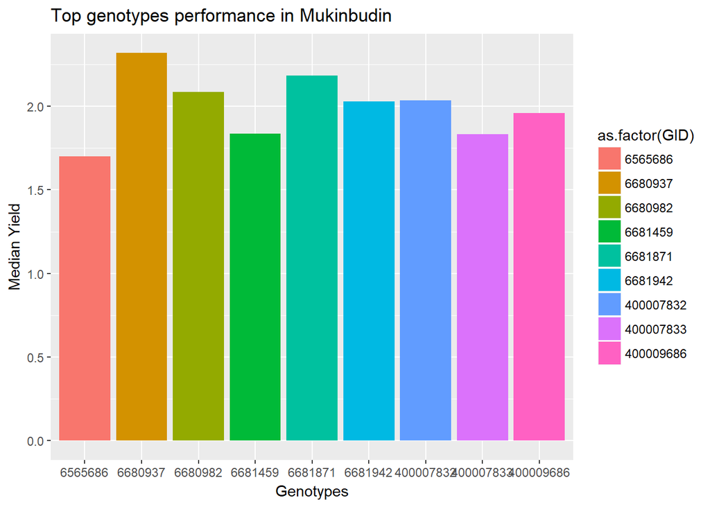

```r
ggplot(genomukinbudin, aes(x = as.factor(GID), y=mediangeno, fill = as.factor(GID))) +
    geom_bar(stat='identity') +

    labs(x = "Genotypes", y = "Median Yield") + ggtitle("Top genotypes performance in Mukinbudin")
```

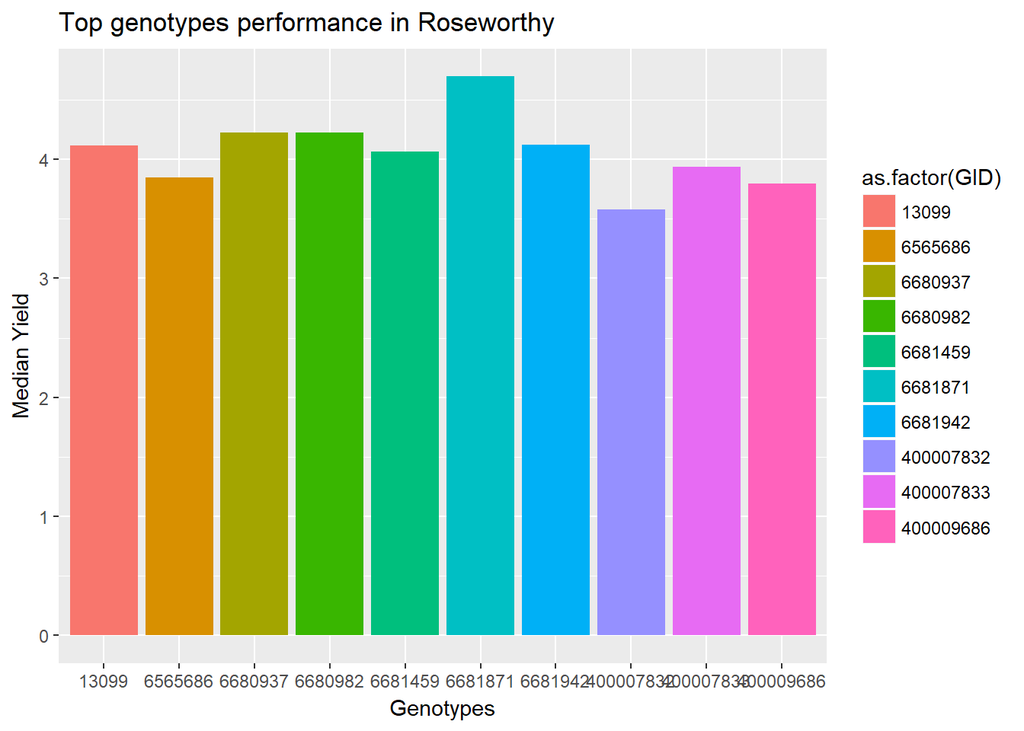

```r
ggplot(genoroseworthy, aes(x = as.factor(GID), y=mediangeno, fill = as.factor(GID))) +
    geom_bar(stat='identity') +

    labs(x = "Genotypes", y = "Median Yield") + ggtitle("Top genotypes performance in Roseworthy")
```